# Family Guy

Isioma Mabatah

8/14/2021

# Summary

## Libraries

```r
library(tidyverse)
library(forcats)
theme_set(theme_minimal())
library(tidytext)
library(ggpubr)
```

## Data

```r
# Load Data
family_raw <- read_csv("Data/Family_guy_dialog.csv")

# Feature processing & cleaing
family <- family_raw %>%
  mutate(index = row_number()) %>%
  select(index, season = seasons, character, dialog) %>%
  mutate(season = str_replace(season, "season", "") %>% as.integer %>% as.factor) %>%
  filter(character != "Maids and Butlers M&B")
```

```r
# color palette
peter <- "#2A6431"
lois <- "#F8784E"
stewie <- "#EB0C42"
brian <- "#E1E0DE"
chris <- "#0576C2"
meg <- "#E06EAA"
quagmire <- "#FAEE40"
cleveland <- "#783204"

family_guy_Palette <- c(brian,chris,cleveland,lois,meg,peter,quagmire,stewie)
```

# Exploratory Data Analysis

```r
family %>% count(season) %>%
  knitr::kable(caption = "Season: Line Count")
```

Season: Line Count

| season | n |
| --- | --- |
| 1 | 43 |
| 2 | 129 |
| 3 | 110 |
| 4 | 155 |
| 5 | 139 |
| 6 | 94 |
| 7 | 80 |
| 8 | 117 |
| 9 | 122 |
| 10 | 168 |
| 12 | 217 |

```r
family %>% count(character) %>% arrange(-n) %>%
  knitr::kable(caption = "Character: Line Count")
```

Character: Line Count

| character | n |
| --- | --- |
| Peter | 394 |
| Stewie | 269 |
| Brian | 211 |
| Lois | 184 |
| Chris | 113 |
| Meg | 85 |
| Quagmire | 78 |
| Cleveland | 40 |

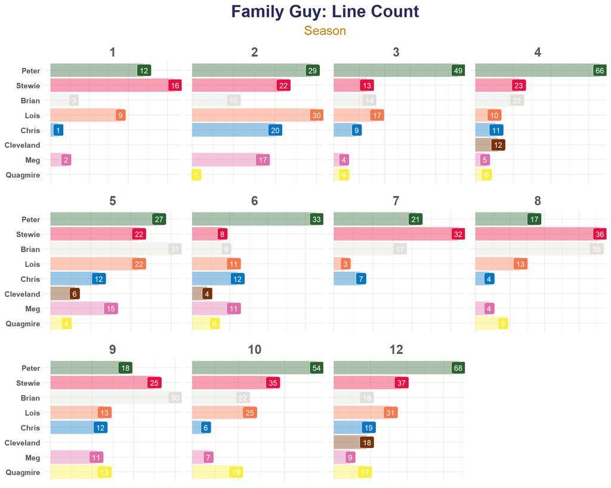

```r
# EDA
family %>%
  count(season, character) %>%
  ggplot(aes(fct_reorder(character, n), n, fill = character)) +
  geom_col(show.legend = FALSE, alpha = 0.4) +
  geom_label(aes(label = n), size = 3, color = "white") +
  facet_wrap(~season, scales = "free_x", nrow = 3) +
  coord_flip() +
  labs(
    title = "Family Guy: Line Count",
    subtitle = "Season"
  ) +
  theme(
    plot.title = element_text(face = "bold", color = "#2A2A57", hjust = 0.5, size = 20),
    plot.subtitle = element_text(color = "darkgoldenrod", hjust = 0.5, size = 15),
    axis.title = element_blank(),
    axis.text.y = element_text(face = "bold"),
    axis.text.x = element_blank(),
    strip.text = element_text(face = "bold", size = 15, color = "grey35"),
    legend.position = "none"
  ) +
  scale_fill_manual(values = family_guy_Palette)
```

## Term Frequency [TABS]

```r
# Stop Words
stops_Family <-
  bind_rows(stop_words,
            tibble(
              word = c("gonna","uh","im","dont","youre","ive","wanna","hey"),
              lexicon = "CUSTOM")
  )
# Bag of Words
family_tidy <- family %>%
  unnest_tokens(word, dialog) %>%
  anti_join(stops_Family)

# Term Frequency
family_tf <- family_tidy %>%
  count(word) %>%
  arrange(-n)

family_tf %>%
  top_n(25, n) %>%
  knitr::kable(caption = "Term Frequency: Top 25")
```

Term Frequency: Top 25

| word | n |
| --- | --- |
| peter | 99 |
| brian | 63 |
| god | 63 |
| lois | 55 |
| meg | 54 |
| chris | 52 |
| yeah | 51 |
| stewie | 38 |
| hell | 36 |
| time | 29 |
| damn | 28 |
| guy | 27 |
| guys | 26 |
| car | 23 |
| dad | 22 |
| laughs | 22 |
| house | 20 |
| people | 20 |
| sex | 20 |
| love | 19 |
| um | 19 |
| quagmire | 18 |
| voice | 18 |
| shut | 17 |
| talking | 17 |
| wow | 17 |

### By Character

[figure not shown]

```r
# Top Words (Character)
family_tidy %>%
  group_by(character) %>%
  count(word) %>%
  arrange(-n) %>%
  top_n(3, n) %>%
  ggplot(aes(n, fct_reorder(word,n), fill = character)) +
  geom_col(show.legend = FALSE, alpha = 0.4) +
  geom_label(aes(label = n), color = "white") +
  facet_wrap(~character, scales = "free") +
  labs(title = "Term Frequency: Top 5",
       x = NULL, y = NULL) +
  theme(
    plot.title = element_text(face = "bold", color = "#2A2A57", hjust = 0.5, size = 20),
    axis.title = element_blank(),
    axis.text.y = element_text(face = "bold"),
    axis.text.x = element_blank(),
    strip.text = element_text(face = "bold", size = 15, color = "grey35"),
    legend.position = "none"
  ) +
  scale_fill_manual(values = family_guy_Palette)
```

> **NOTE (Term Frequecy):** Based on the Term Frequency
> - Most of the characters are talking the Peter the most *(Lois, Brain, Quagmire)*.
> - Peter and Lois talks to each other the most.
> - Brian talks to Peter and Stewie the most.
> - Stewie talks to Brian the most.
> - Chris and Meg talks to each other the most.
> - Meg talks to Chris the most.

### By Season

[figure not shown]

```r
# Top Words (Season 1-6)
family_tidy %>%
  filter(season %in% 1:6) %>%
  group_by(character) %>%
  count(word) %>%
  arrange(-n) %>%
  top_n(4, n) %>%
  ggplot(aes(n, fct_reorder(word,n), fill = character)) +
  geom_col(show.legend = FALSE, alpha = 0.4) +
  geom_label(aes(label = n), color = "white") +
  facet_wrap(~character, scales = "free") +
  labs(
    title = "Term Frequency: Top 5",
    subtitle = "Season: 1-6",
    x = NULL, y = NULL
  ) +
 theme(
    plot.title = element_text(face = "bold", color = "#2A2A57", hjust = 0.5, size = 20),
    plot.subtitle = element_text(color = "darkgoldenrod", hjust = 0.5, size = 15),
    axis.text.y = element_text(face = "bold"),
    axis.text.x = element_blank(),
    strip.text = element_text(face = "bold", size = 15, color = "grey35"),
    legend.position = "none"
  ) +
  scale_fill_manual(values = family_guy_Palette)
```

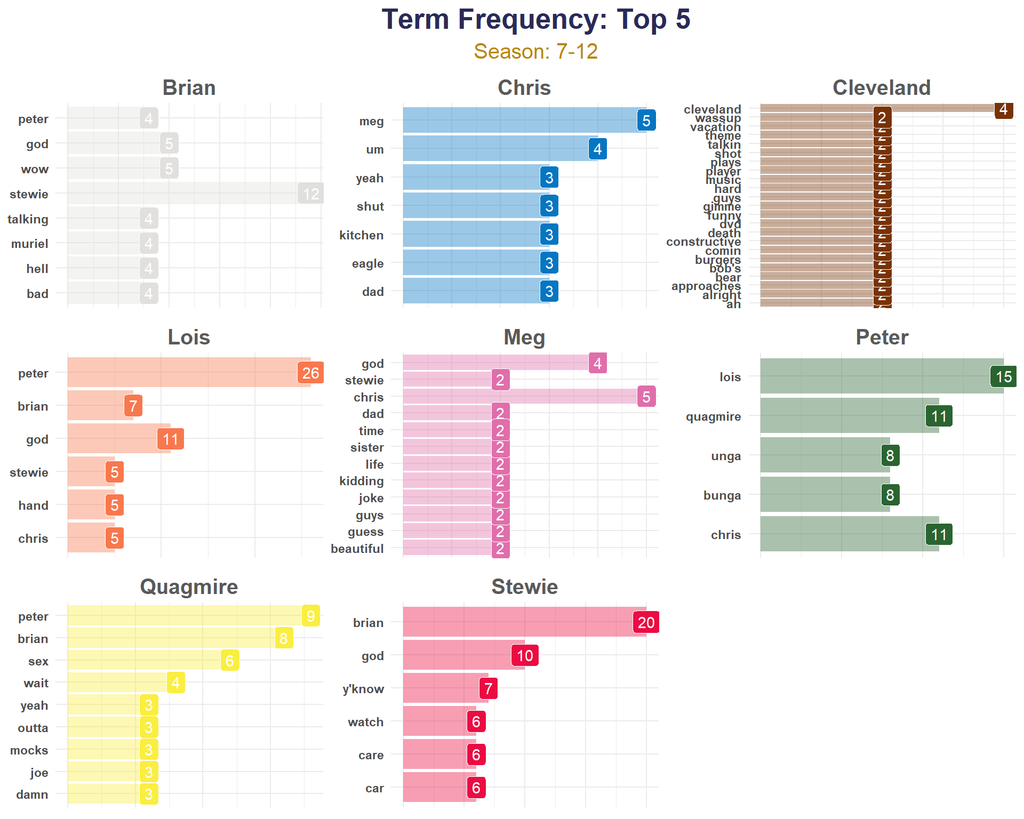

```r
# Top Words (Season 7-12)
family_tidy %>%
  filter(season %in% 7:12) %>%
  group_by(character) %>%
  count(word) %>%
  arrange(-n) %>%
  top_n(5, n) %>%
  ggplot(aes(n, fct_reorder(word,n), fill = character)) +
  geom_col(show.legend = FALSE, alpha = 0.4) +
  geom_label(aes(label = n), color = "white") +
  facet_wrap(~character, scales = "free") +
  labs(
    title = "Term Frequency: Top 5",
    subtitle = "Season: 7-12",
    x = NULL, y = NULL
  ) +
  theme(
    plot.title = element_text(face = "bold", color = "#2A2A57", hjust = 0.5, size = 20),
    plot.subtitle = element_text(color = "darkgoldenrod", hjust = 0.5, size = 15),
    axis.text.y = element_text(face = "bold"),
    axis.text.x = element_blank(),
    strip.text = element_text(face = "bold", size = 15, color = "grey35"),
    legend.position = "none"
  ) +
  scale_fill_manual(values = family_guy_Palette)
```

> **NOTE (Term Frequency):** Based on teh Term Frequency by Season

> *Season 1-6*
> - The majority of the dialogue is between Peter and Lois
> - Brain also refers to Peter frequently.
> - Stewie refers to Brian Frequently

> *Season 7-12*
> - The majority of the dialogue is spread betweeen Peter and Lois and Stewie and Brian.
> - Brian talks to Stewie more during the back half of the Series as opposed to Peter.
> - Quagmire gets more airtime consisting of him talking to Peter.
> - Chris and Meg also gets more airtime talking to each other

### Bigram

```r
# Bigram
family_bigram <- family %>%
  unnest_tokens(bigram, dialog,
                token = "ngrams",
                n = 2)
family_bigram_clean_seperate <- family_bigram %>%
  separate(bigram, c("word1","word2"), sep = " ") %>%
  filter(!word1 %in% stop_words$word) %>%
  filter(!word2 %in% stop_words$word)

family_bigram_clean_unite <-
  family_bigram_clean_seperate %>%
  unite(bigram, word1, word2, sep = " ") %>%
  filter(bigram != "NA NA")

family_bigram_clean_unite %>% count(bigram) %>% arrange(-n) %>% top_n(25, n) %>%
  knitr::kable(caption = "Bigram: Top 25")
```

Bigram: Top 25

| bigram | n |
| --- | --- |
| unga bunga | 9 |
| meg meg | 6 |
| bam bam | 5 |
| brian brian | 4 |
| bunga unga | 4 |
| cool hwhip | 4 |
| damn dials | 4 |
| fucking car | 4 |
| glenn quagmire | 4 |
| holy crap | 4 |
| ice cream | 4 |
| lois damn | 4 |
| peter griffin | 4 |
| uh yeah | 4 |
| care bear | 3 |
| careful careful | 3 |
| chris honey | 3 |
| family circus | 3 |
| giggity giggity | 3 |
| hey hey | 3 |
| james woods | 3 |
| music video | 3 |
| olive juice | 3 |
| trap jaw | 3 |
| whoa whoa | 3 |
| youre gonna | 3 |

[figure not shown]

```r
# Top Bigram: Popular Words (Character)
family_bigram_clean_unite %>%
  group_by(character) %>%
  count(bigram) %>%
  arrange(-n) %>%
  top_n(5, n) %>%
  ggplot(aes(n, fct_reorder(bigram,n), fill = character)) +
  geom_col(show.legend = FALSE) +
  facet_wrap(~character, scales = "free") +
  labs(title = "Top Bigram") +
  theme(
    plot.title = element_text(face = "bold", color = "#2A2A57", hjust = 0.3, size = 20),
    axis.title = element_blank(),
    axis.text.y = element_text(face = "bold")
  ) +
  scale_fill_manual(values = family_guy_Palette)
```

[figure not shown]

```r
# Top Bigram: (Season 1-6)
family_bigram_clean_unite %>%
  group_by(character) %>%
  count(bigram) %>%
  arrange(-n) %>%
  top_n(3, n) %>%
  ungroup() %>%
  ggplot(aes(n, fct_reorder(bigram,n), fill = character)) +
  geom_col(show.legend = FALSE) +
  facet_wrap(~character, scales = "free") +
  labs(
    title = "Top Bigrams",
    subtitle = "Season: ALL",
    x = NULL, y = NULL
  ) +
  theme(
    plot.title = element_text(face = "bold", color = "#2A2A57", hjust = 0.3, size = 20),
    plot.subtitle = element_text(color = "darkgoldenrod", hjust = 0.3, size = 15),
    axis.title = element_blank(),
    axis.text.y = element_text(face = "bold")
  ) +
  scale_fill_manual(values = family_guy_Palette)
```

# Sentiment Analysis [TABS]

## BING

```r
family_bing <- family_tidy %>% inner_join(get_sentiments("bing"))
family_bing %>% count(sentiment)
```

```
## # A tibble: 2 x 2
##   sentiment     n
##   <chr>     <int>
## 1 negative    670
## 2 positive    270
```

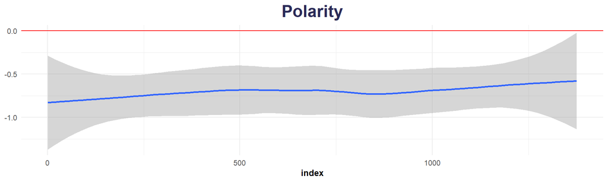

```r
# By Index
family_bing %>%
  count(index, season, sentiment) %>%
  spread(sentiment, n, fill = 0) %>%
  mutate(polarity = positive - negative) %>%
  ggplot(aes(index, polarity)) +
  geom_smooth(show.legend = FALSE) +
  geom_hline(yintercept = 0, color = "red") +
  labs(
    title = "Polarity",
    y = NULL
  ) +
  theme(
    plot.title = element_text(face = "bold", color = "#2A2A57", hjust = 0.5, size = 20),
    plot.subtitle = element_text(color = "darkgoldenrod", hjust = 0.5, size = 15),
    axis.title.x = element_text(face = "bold", size = 10)
  )
```

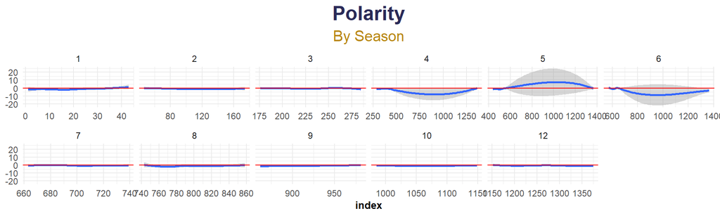

```r
# By season
family_bing %>%
  count(index, season, sentiment) %>%
  spread(sentiment, n, fill = 0) %>%
  mutate(polarity = positive - negative) %>%
  ggplot(aes(index, polarity)) +
  geom_smooth(show.legend = FALSE) +
  geom_hline(yintercept = 0, color = "red") +
  facet_wrap(~season, scales = "free_x", nrow = 2) +
  labs(
    title = "Polarity",
    subtitle = "By Season",
    y = NULL
  ) +
  theme(
    plot.title = element_text(face = "bold", color = "#2A2A57", hjust = 0.5, size = 20),
    plot.subtitle = element_text(color = "darkgoldenrod", hjust = 0.5, size = 15),
    axis.title.x = element_text(face = "bold", size = 10)
  )
```

[figure not shown]

```r
# By Character
# - Peter
gg_Polarity_Peter <- family_bing %>%
  filter(character == "Peter") %>%
  count(index, season, sentiment) %>%
  spread(sentiment, n, fill = 0) %>%
  mutate(polarity = positive - negative) %>%
  ggplot(aes(index, polarity)) +
  geom_smooth(show.legend = FALSE, size = 1, color = peter) +
  geom_hline(yintercept = 0, color = "red", linetype = 2, alpha = 0.3) +
  facet_wrap(~season, scales = "free_x", nrow = 1) +
  labs(title = "Polarity throughout the Series",
       subtitle = "Peter",
       x = "Season", y = NULL) +
  theme_minimal() +
    theme(
      plot.title = element_text(face = "bold", color = "#2A2A57", hjust = 0.5, size = 12),
      plot.subtitle = element_text(color = "darkgoldenrod", hjust = 0.5, size = 6),
      axis.title.x = element_text(face = "bold", size = 10),
      axis.text.x = element_blank()
)
# - Lois
gg_Polarity_Lois <- family_bing %>%
    filter(character == "Lois") %>%
    count(index, season, sentiment) %>%
    spread(sentiment, n, fill = 0) %>%
    mutate(polarity = positive - negative) %>%
    ggplot(aes(index, polarity)) +
    geom_smooth(show.legend = FALSE, size = 1, color = lois) +
    geom_hline(yintercept = 0, color = "red", linetype = 2, alpha = 0.3) +
    facet_wrap(~season, scales = "free_x", nrow = 1) +
    labs(title = "Polarity throughout the Series",
         subtitle = "Lois",
         x = NULL, y = NULL) +
    theme_minimal() +
      theme(
        plot.title = element_blank(),
        plot.subtitle = element_text(color = "darkgoldenrod", hjust = 0.5, size = 10),
        axis.title.x = element_text(face = "bold", size = 6),
        axis.text.x = element_blank()
      )
# - Stewie
gg_Polarity_Stewie <- family_bing %>%
    filter(character == "Stewie") %>%
    count(index, season, sentiment) %>%
    spread(sentiment, n, fill = 0) %>%
    mutate(polarity = positive - negative) %>%
    ggplot(aes(index, polarity)) +
    geom_smooth(show.legend = FALSE, size = 1, color = stewie) +
    geom_hline(yintercept = 0, color = "red", linetype = 2, alpha = 0.3) +
    facet_wrap(~season, scales = "free_x", nrow = 1) +
    labs(title = "Polarity throughout the Series",
         subtitle = "Stewie",
         x = NULL, y = NULL) +
    theme_minimal() +
      theme(
        plot.title = element_blank(),
        plot.subtitle = element_text(color = "darkgoldenrod", hjust = 0.5, size = 10),
        axis.title.x = element_text(face = "bold", size = 10),
        axis.text.x = element_blank()
      )
# - Brian
gg_Polarity_Brian <- family_bing %>%
    filter(character == "Brian") %>%
    count(index, season, sentiment) %>%
    spread(sentiment, n, fill = 0) %>%
    mutate(polarity = positive - negative) %>%
    ggplot(aes(index, polarity)) +
    geom_smooth(show.legend = FALSE, size = 1, color = brian) +
    geom_hline(yintercept = 0, color = "red", linetype = 2, alpha = 0.3) +
    facet_wrap(~season, scales = "free_x", nrow = 1) +
    labs(title = "Polarity throughout the Series",
         subtitle = "Brian",
         x = NULL, y = NULL) +
    theme_minimal() +
      theme(
        plot.title = element_blank(),
        plot.subtitle = element_text(color = "darkgoldenrod", hjust = 0.5, size = 10),
        axis.title.x = element_text(face = "bold", size = 10),
        axis.text.x = element_blank()
      )
# - Chris
gg_Polarity_Chris <- family_bing %>%
    filter(character == "Chris") %>%
    count(index, season, sentiment) %>%
    spread(sentiment, n, fill = 0) %>%
    mutate(polarity = positive - negative) %>%
    ggplot(aes(index, polarity)) +
    geom_smooth(show.legend = FALSE, size = 1, color = chris) +
    geom_hline(yintercept = 0, color = "red", linetype = 2, alpha = 0.3) +
    facet_wrap(~season, scales = "free_x", nrow = 1) +
    labs(title = "Polarity throughout the Series",
         subtitle = "Chris",
         x = NULL, y = NULL) +
    theme_minimal() +
      theme(
        plot.title = element_blank(),
        plot.subtitle = element_text(color = "darkgoldenrod", hjust = 0.5, size = 10),
        axis.title.x = element_text(face = "bold", size = 10),
        axis.text.x = element_blank()
      )
# - Meg
gg_Polarity_Meg <- family_bing %>%
    filter(character == "Meg") %>%
    count(index, season, sentiment) %>%
    spread(sentiment, n, fill = 0) %>%
    mutate(polarity = positive - negative) %>%
    ggplot(aes(index, polarity)) +
    geom_smooth(show.legend = FALSE, size = 1, color = meg) +
    geom_hline(yintercept = 0, color = "red", linetype = 2, alpha = 0.3) +
    facet_wrap(~season, scales = "free_x", nrow = 1) +
    labs(title = "Polarity throughout the Series",
         subtitle = "Meg",
         x = NULL, y = NULL) +
    theme_minimal() +
      theme(
        plot.title = element_blank(),
        plot.subtitle = element_text(color = "darkgoldenrod", hjust = 0.5, size = 10),
        axis.title.x = element_text(face = "bold", size = 10),
        axis.text.x = element_blank()
      )

# Visual
ggarrange(gg_Polarity_Peter,gg_Polarity_Lois, gg_Polarity_Stewie,
          ncol = 1)
```

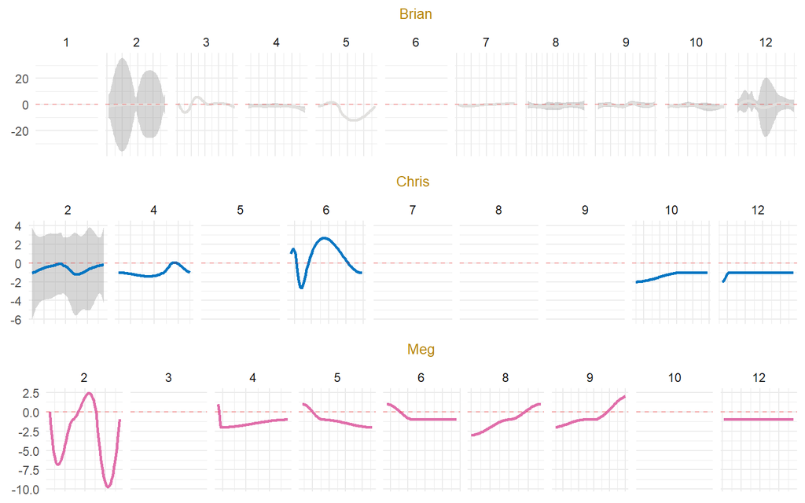

```r
ggarrange(gg_Polarity_Brian, gg_Polarity_Chris, gg_Polarity_Meg,
          ncol = 1)
```

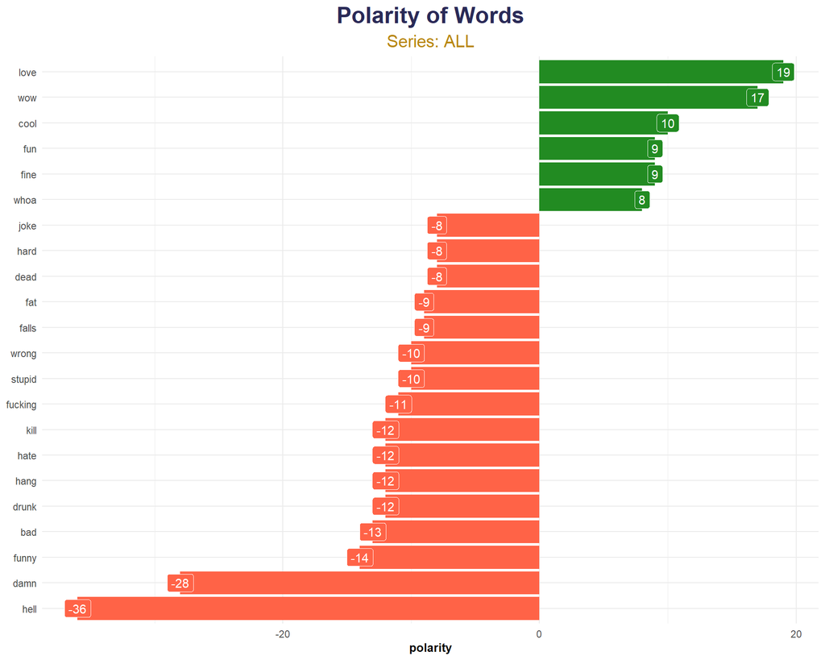

```r
family_bing %>%
  count(word, sentiment) %>%
  spread(sentiment, n, fill = 0) %>%
  mutate(polarity = positive - negative) %>%
  mutate(pos_neg = ifelse(polarity > 0, "positive","negative")) %>%
  filter(abs(polarity) >= 8) %>%
  ggplot(aes(fct_reorder(word, polarity), polarity, fill = pos_neg)) +
  geom_col(show.legend = FALSE) +
  geom_label(aes(label = polarity), color = "white") +
  coord_flip() +
  labs(title = "Polarity of Words",
       subtitle = "Series: ALL",
       x = NULL
  ) +
  theme(
    plot.title = element_text(face = "bold", color = "#2A2A57", hjust = 0.5, size = 20),
    plot.subtitle = element_text(color = "darkgoldenrod", hjust = 0.5, size = 15),
    axis.title.x = element_text(face = "bold", size = 10),
    legend.position = "none"
  ) +
  scale_fill_manual(values = c("tomato", "forestgreen"))
```

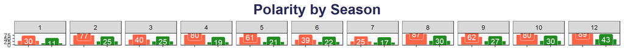

```r
family_bing %>%
  group_by(season) %>%
  count(sentiment) %>%
  ggplot(aes(sentiment,n, fill = sentiment)) +
  geom_col(show.legend = FALSE) +
  geom_label(aes(label = n), color = "white") +
  facet_wrap(~season, nrow = 1) +
  theme_bw() +
  labs(
    title = "Polarity by Season",
    x = NULL, y = NULL
  ) +
  theme(
    plot.title = element_text(face = "bold", color = "#2A2A57", hjust = 0.5, size = 20),
    plot.subtitle = element_text(color = "darkgoldenrod", hjust = 0.5, size = 15),
    axis.title.x = element_text(face = "bold", size = 10),
    axis.text.x = element_blank(),
    legend.position = "none"
  ) +
  scale_fill_manual(values = c("tomato","forestgreen"))
```

```r
# Dataframe
family_bing %>%
  count(season, sentiment) %>%
  spread(sentiment, n) %>%
  mutate(overall = positive - negative)
```

```
## # A tibble: 11 x 4
##    season negative positive overall
##    <fct>     <int>    <int>   <int>
##  1 1            30       11     -19
##  2 2            77       25     -52
##  3 3            40       25     -15
##  4 4            80       19     -61
##  5 5            61       21     -40
##  6 6            39       22     -17
##  7 7            25       17      -8
##  8 8            87       30     -57
##  9 9            62       27     -35
## 10 10           80       30     -50
## 11 12           89       43     -46
```

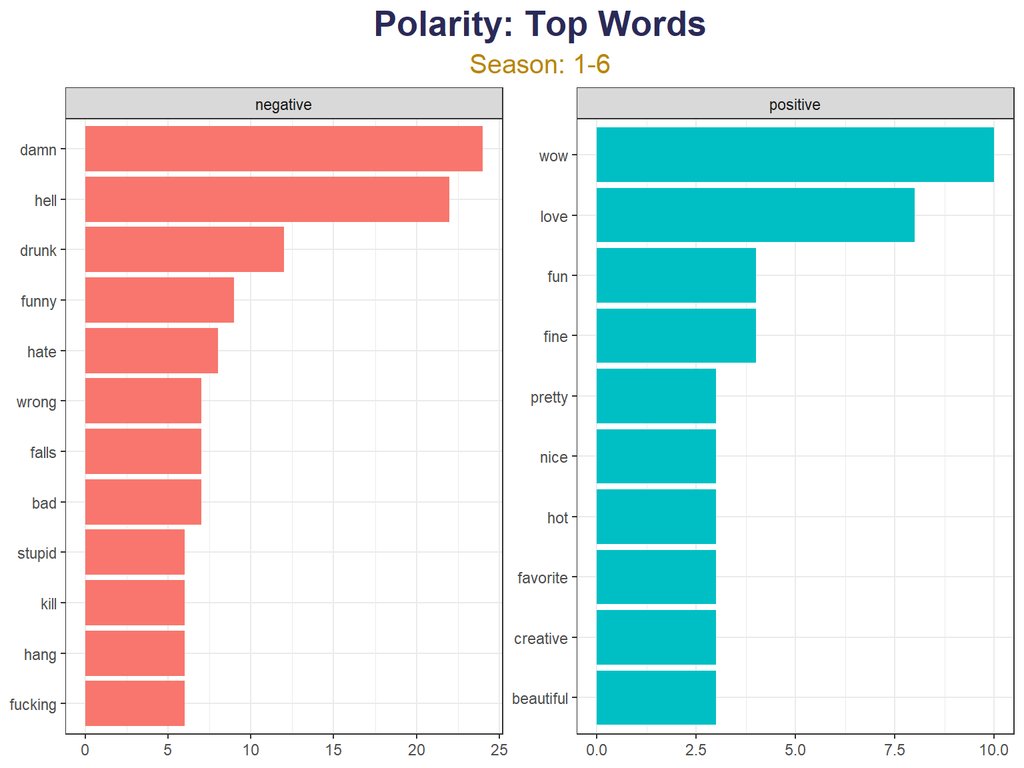

```r
# Season: 1-6
family_bing %>%
  filter(season %in% 1:6) %>%
  group_by(sentiment) %>%
  count(word, sort = TRUE) %>%
  top_n(10, n) %>%
  ggplot(aes(n, fct_reorder(word, n), fill = sentiment)) +
  geom_col(show.legend = FALSE) +
  facet_wrap(~sentiment, scales = "free") +
  theme_bw() +
  labs(
    title = "Polarity: Top Words",
    subtitle = "Season: 1-6",
    x = NULL, y = NULL
  ) +
  theme(
    plot.title = element_text(face = "bold", color = "#2A2A57", hjust = 0.5, size = 20),
    plot.subtitle = element_text(color = "darkgoldenrod", hjust = 0.5, size = 15),
    axis.title.x = element_text(face = "bold", size = 10)
  )
```

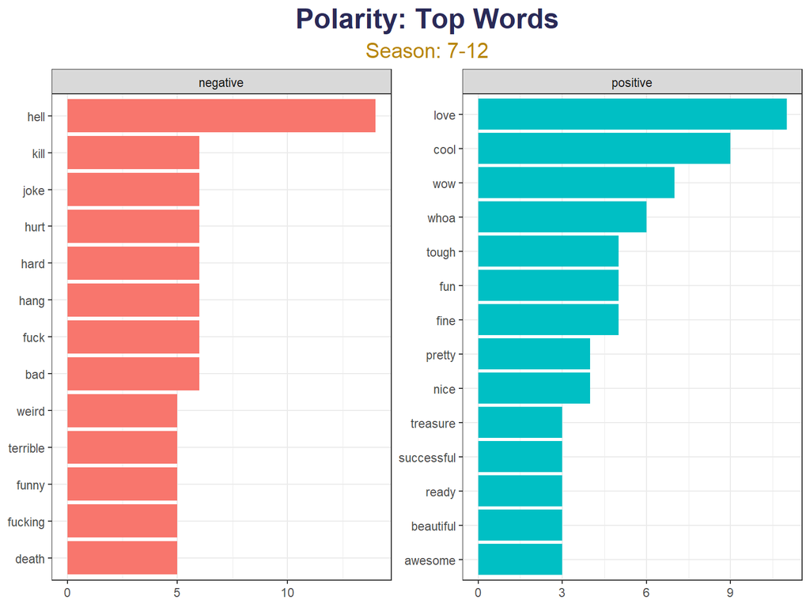

```r
# Season: 7-12
family_bing %>%
  filter(season %in% 7:12) %>%
  group_by(sentiment) %>%
  count(word, sort = TRUE) %>%
  top_n(10, n) %>%
  ggplot(aes(n, fct_reorder(word, n), fill = sentiment)) +
  geom_col(show.legend = FALSE) +
  facet_wrap(~sentiment, scales = "free") +
  theme_bw() +
  labs(
    title = "Polarity: Top Words",
    subtitle = "Season: 7-12",
    x = NULL, y = NULL
  ) +
  theme(
    plot.title = element_text(face = "bold", color = "#2A2A57", hjust = 0.5, size = 20),
    plot.subtitle = element_text(color = "darkgoldenrod", hjust = 0.5, size = 15),
    axis.title.x = element_text(face = "bold", size = 10)
  )
```

[figure not shown]

```r
# Total by Character
family_bing %>%
  group_by(character) %>%
  count(sentiment) %>%
  ggplot(aes(sentiment, n, fill = sentiment)) +
  geom_col(show.legend = FALSE) +
  geom_label(aes(label = n), color = "white") +
  facet_wrap(~character, nrow = 1) +
  labs(
    title = "Polarity by Character",
    x = NULL, y = NULL
  ) +
  theme(
    plot.title = element_text(face = "bold", color = "#2A2A57", hjust = 0.5, size = 20),
    plot.subtitle = element_text(color = "darkgoldenrod", hjust = 0.5, size = 15),
    axis.title.x = element_text(face = "bold", size = 10),
    axis.text = element_blank(),
    legend.position = "none"
  ) +
  scale_fill_manual(values = c("tomato","forestgreen"))
```

[figure not shown]

```r
# % Polarity by Season
family_bing %>%
  count(season, character, sentiment) %>%
  ggplot(aes(character, n, fill = sentiment)) +
  geom_col(position = "fill", alpha = 0.5, show.legend = FALSE) +
  facet_wrap(~ season, scales = "free_x", nrow = 1) +
  theme_bw() +
  theme(axis.text.x = element_text(angle = 90)) +
  labs(title = "% Polarity of Characters by Season",
       x = NULL, y = NULL) +
  theme(
    plot.title = element_text(face = "bold", color = "#2A2A57", hjust = 0.5, size = 20),
    plot.subtitle = element_text(color = "darkgoldenrod", hjust = 0.5, size = 15),
    axis.text.y = element_blank(),
    axis.text.x = element_text(face = "italic", size = 7, vjust = 1),
    legend.position = "none"
  ) +
  scale_fill_manual(values = c("tomato","forestgreen"))
```

[figure not shown]

```r
# Character Top Words: Positive
family_bing %>%
  filter(sentiment == "positive") %>%
  group_by(character) %>%
  count(word) %>%
  top_n(3, n) %>%
  ungroup() %>%
  ggplot(aes(n, fct_reorder(word, n), fill = character)) +
  geom_col(show.legend = FALSE, alpha = 0.5) +
  geom_label(aes(label = n), color = "white") +
  facet_wrap(~ character, scales = "free", nrow = 2) +
  labs(
    title = "Top Words",
    subtitle = "Positive",
    x = NULL, y = NULL
  ) +
  theme(
      plot.title = element_text(face = "bold", color = "#2A2A57", hjust = 0.5, size = 20),
      plot.subtitle = element_text(color = "forestgreen", hjust = 0.5, size = 15),
      axis.text.x = element_blank(),
      strip.text = element_text(face = "bold", size = 15, color = "grey35"),
      legend.position = "none"
  ) +
  scale_fill_manual(values = family_guy_Palette)
```